# Support

Kimberly A. Brink

February 15, 2017

### Demographics.

There were 60 participants.

Now there are 55 participants after removing for computer error.

Now there are 55 participants after removing for crawling.

Age in months

| Min. | 1st Qu. | Median | Mean | 3rd Qu. | Max. |
| --- | --- | --- | --- | --- | --- |
| 4.8 | 6.95 | 7.3 | 7.216 | 7.55 | 7.833 |

There are 26 females in the sample.

The first date of test was 2016-01-15.

The most recent date of test was 2017-02-13.

# Tests for normality

[figure not shown]

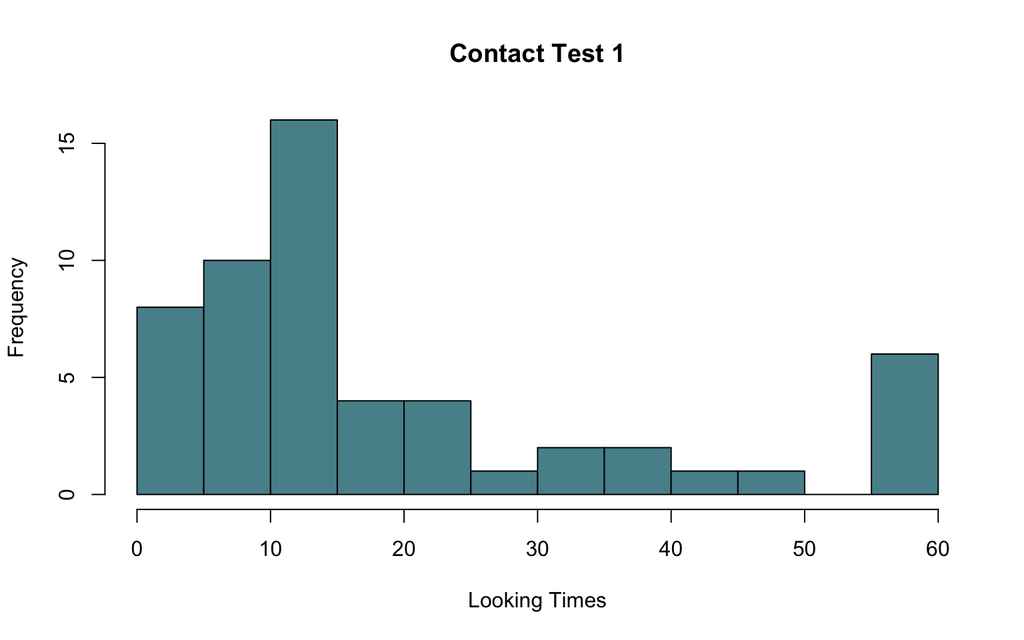

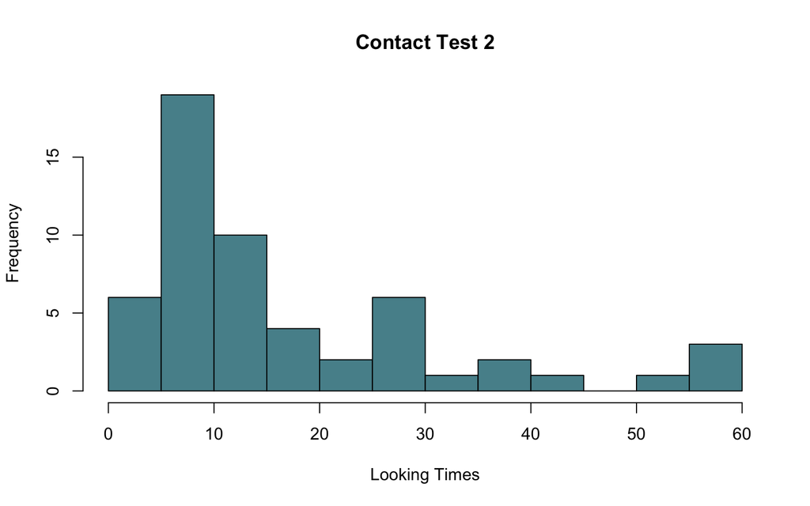

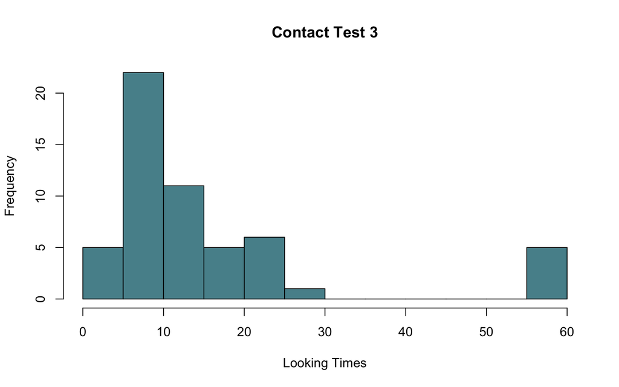

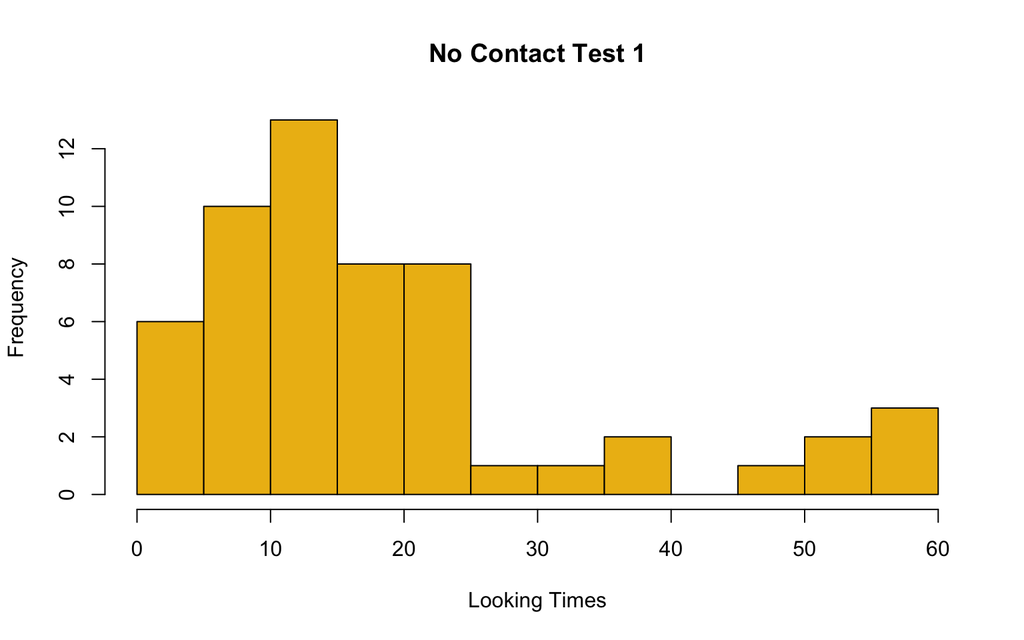

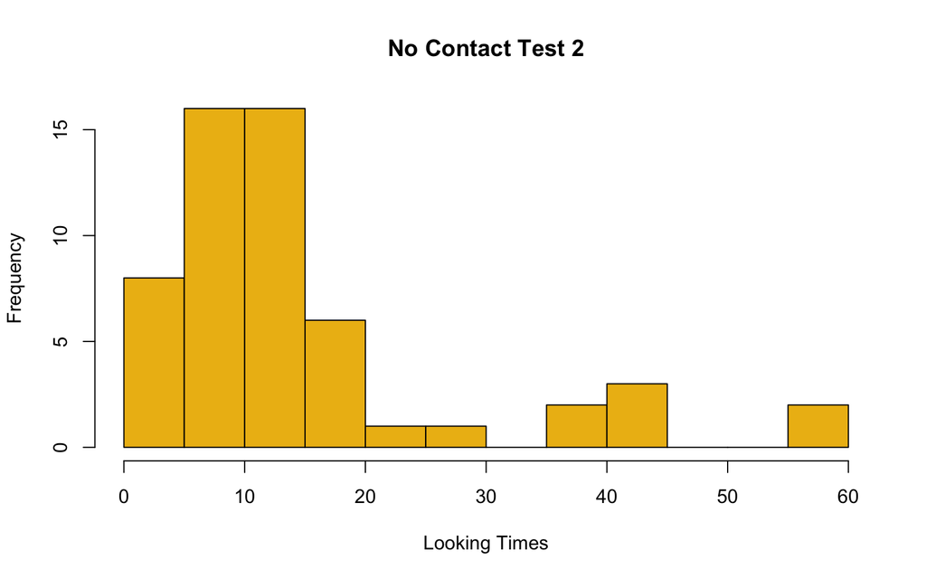

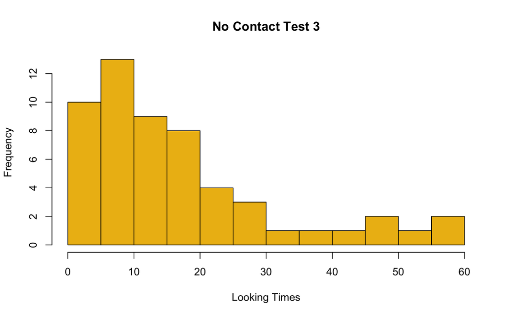

# Non-Parametric Analyses

## Bar Graph: Median by Test Trial

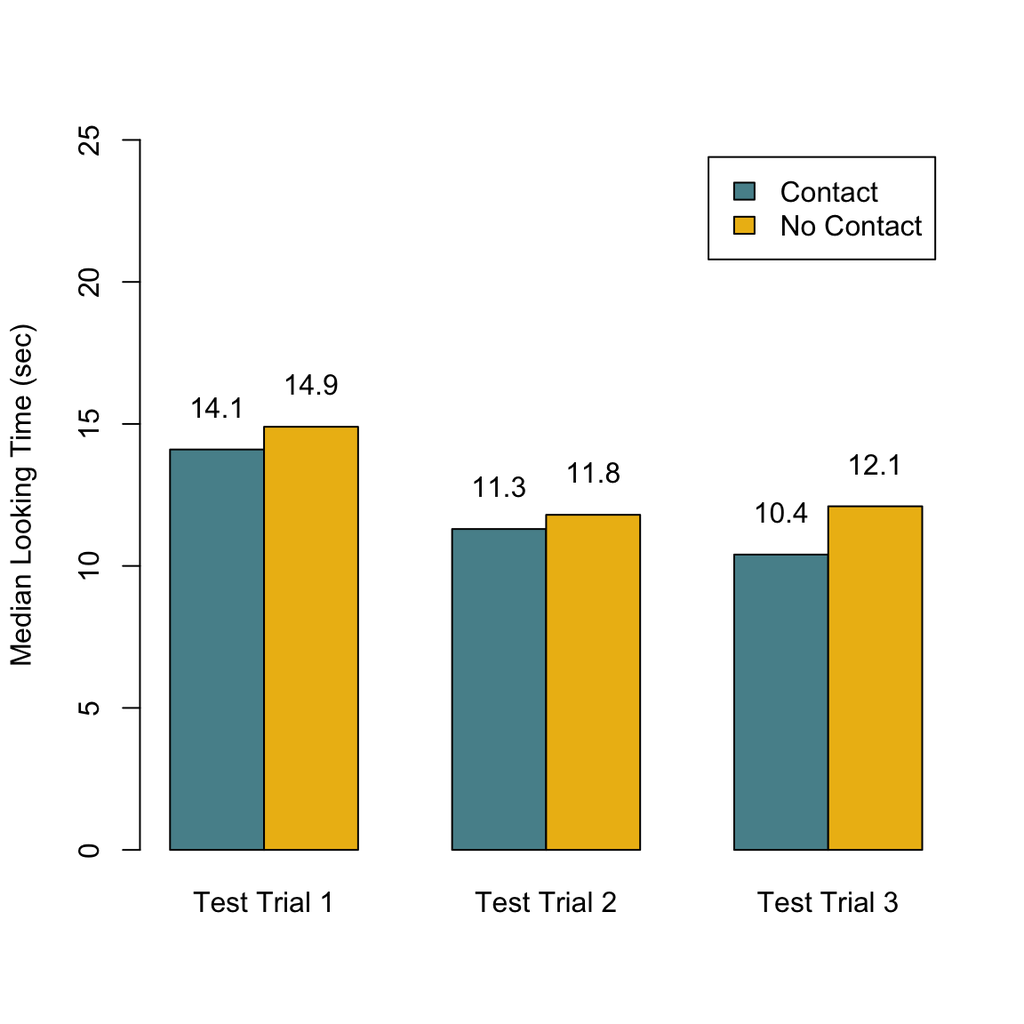

There was no difference in looking times between the first Contact test event (Median = 14.1) and the first No Contact event (Median = 14.9), (Wilcoxon *Z* = -0.15, *p* = 0.88)

There was no difference in looking times between the second Contact test event (Median = 11.3) and the second No Contact event (Median = 11.8), (Wilcoxon *Z* = -0.86, *p* = 0.39).

There was no difference in looking times between the third Contact test event (Median = 10.4) and the third No Contact event (Median = 12.1), (Wilcoxon *Z* = -0.82, *p* = 0.41).

## Bar Graph: Median by Test Trial (Younger infants)

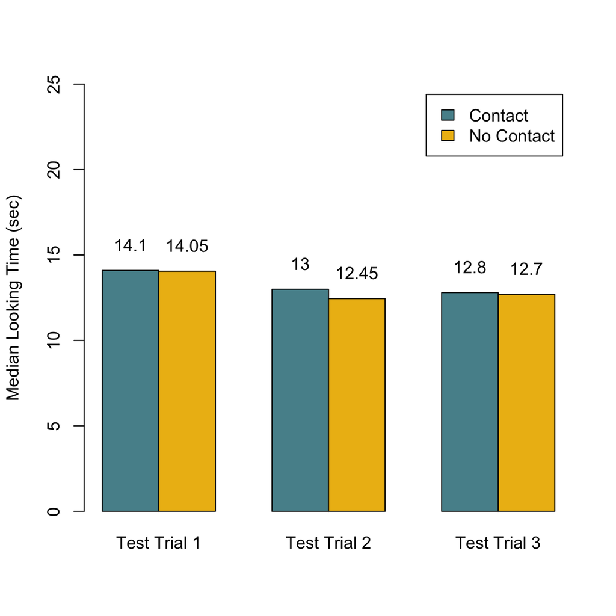

For younger infants, there was no difference in looking times between the first Contact test event (Median = 14.1) and the first No Contact event (Median = 14.05), (Wilcoxon *Z* = -0.23, *p* = 0.82)

For younger infants, there was no difference in looking times between the second Contact test event (Median = 13) and the second No Contact event (Median = 12.45), (Wilcoxon *Z* = -1.52, *p* = 0.13).

For younger infants, there was no difference in looking times between the third Contact test event (Median = 12.8) and the third No Contact event (Median = 12.7), (Wilcoxon *Z* = -0.16, *p* = 0.87).

## Bar Graph: Median by Test Trial (Older infants)

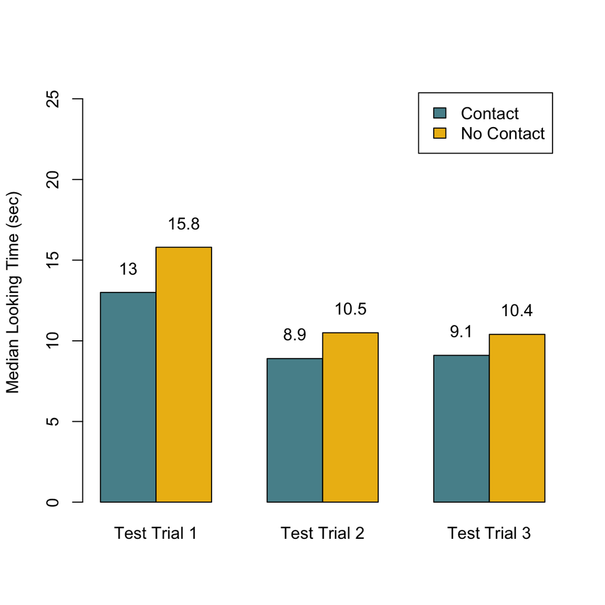

There was no difference in looking times between the first Contact test event (Median = 13) and the first No Contact event (Median = 15.8), (Wilcoxon *Z* = -0.26, *p* = 0.79)

There was no difference in looking times between the second Contact test event (Median = 8.9) and the second No Contact event (Median = 10.5), (Wilcoxon *Z* = -0.31, *p* = 0.75).

There was no difference in looking times between the third Contact test event (Median = 9.1) and the third No Contact event (Median = 10.4), (Wilcoxon *Z* = -1.28, *p* = 0.2).

# Parametric Analyses

## Bar Graph: Means by Test Trial (All infants)

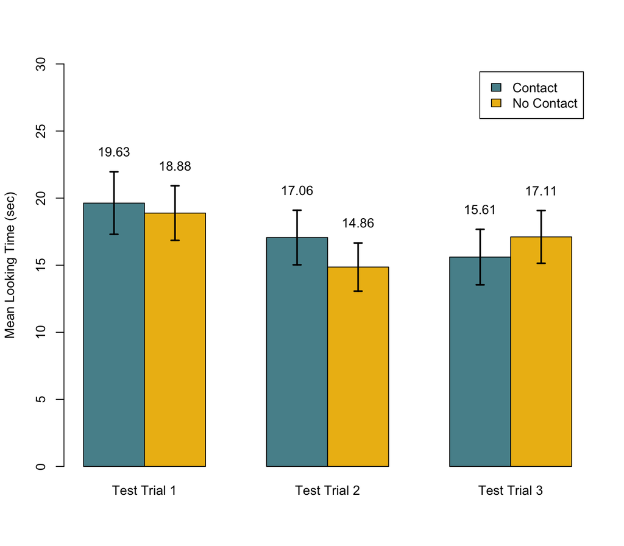

There was no difference in looking times between the first Possible test event (M = 19.63) and the first Impossible event (M = 18.88), (t(54) = -0.31, *p* = 0.76).

There was no difference in looking times between the second Possible test event (M = 17.06) and the second Impossible event (M = 14.86), (t(54) = -1.02, *p* = 0.31).

There was no difference in looking times between the third Possible test event (M = 15.61) and the third Impossible event (M = 17.11), (t(54) = 0.66, *p* = 0.51).

# Bar Graph: Means by Test Trial (Younger infants)

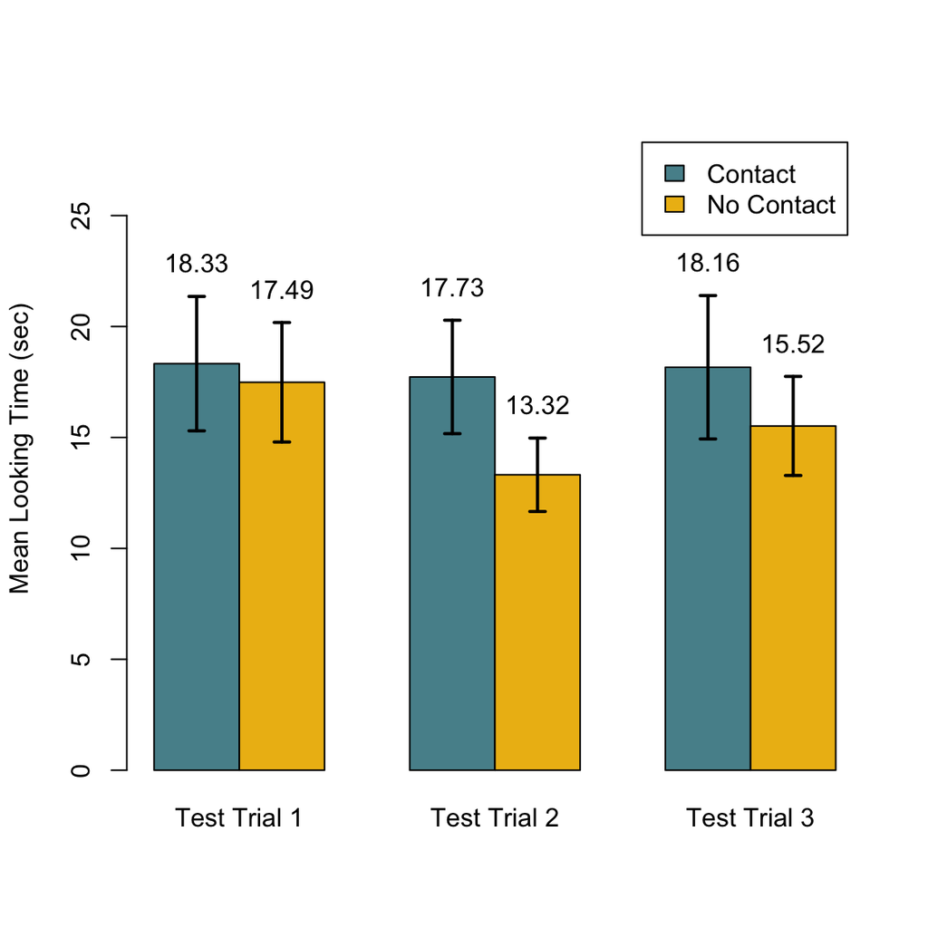

For infants younger than 7.3 months, there was no difference in looking times between the first Possible test event (M = 18.33) and the first Impossible event (M = 17.49), (t(29) = -0.24, *p* = 0.81).

For infants younger than 7.3 months, there was no difference in looking times between the second Possible test event (M = 17.73) and the second Impossible event (M = 13.32), (t(29) = -1.57, *p* = 0.13).

For infants younger than 7.3 months, there was no difference in looking times between the third Possible test event (M = 18.16) and the third Impossible event (M = 15.52), (t(29) = -0.89, *p* = 0.38).

# Bar Graph: Means by Test Trial (Older infants)

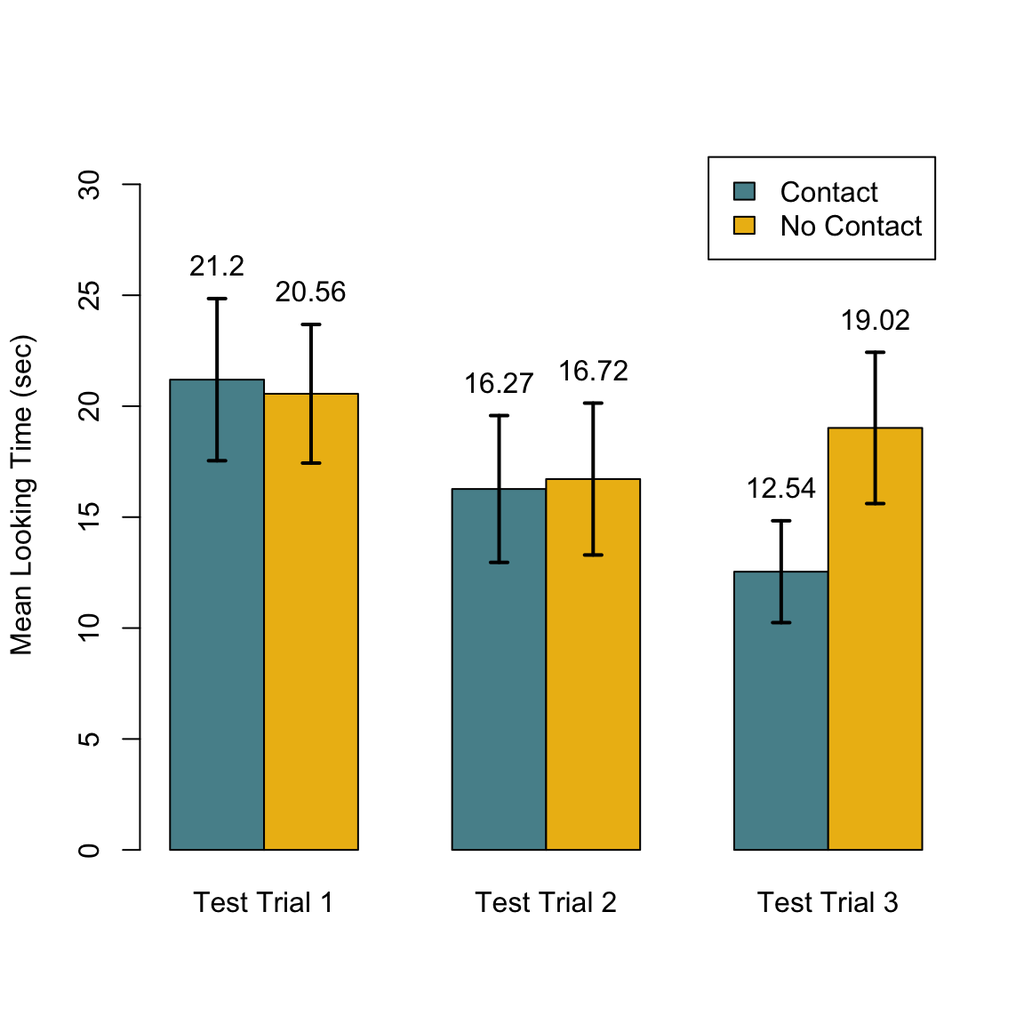

For infants older than 7.3 months, there was no difference in looking times between the first Possible test event (M = 21.2) and the first Impossible event (M = 20.56), (t(24) = -0.2, *p* = 0.85).

For infants older than 7.3 months, there was no difference in looking times between the second Possible test event (M = 16.27) and the second Impossible event (M = 16.72), (t(24) = 0.13, *p* = 0.89).

For infants older than 7.3 months, there was no difference in looking times between the third Possible test event (M = 12.54) and the third Impossible event (M = 19.02), (t(24) = 1.97, *p* = 0.06).

## Bar Graph: Average Looking Time Across Condition

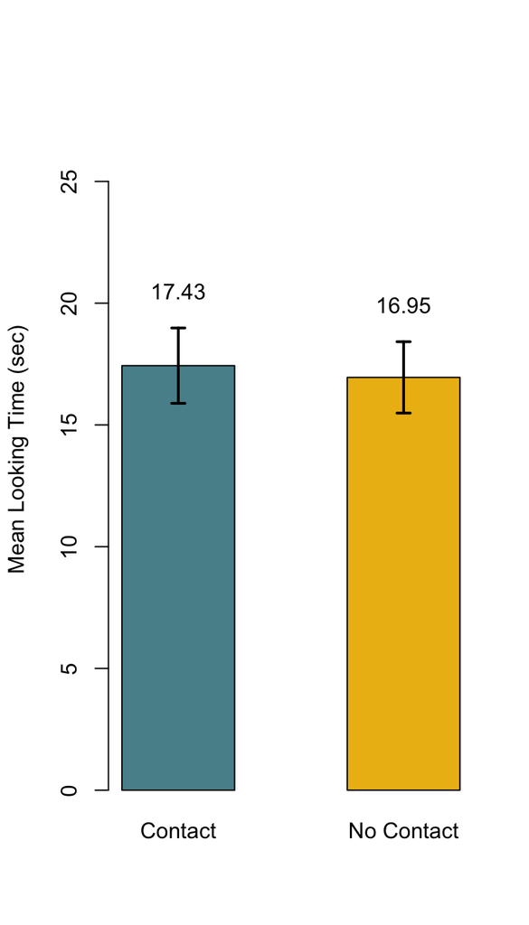

There was no difference in looking times between the average looking time of all three Possible test events (M = 17.43) and the average looking time of all three Impossible events (M = 16.95), (t(54) = 0.32, *p* = 0.75).

# Between-Subject Analyses

## Bar Graph: Medians of first trial (Between-Subject)

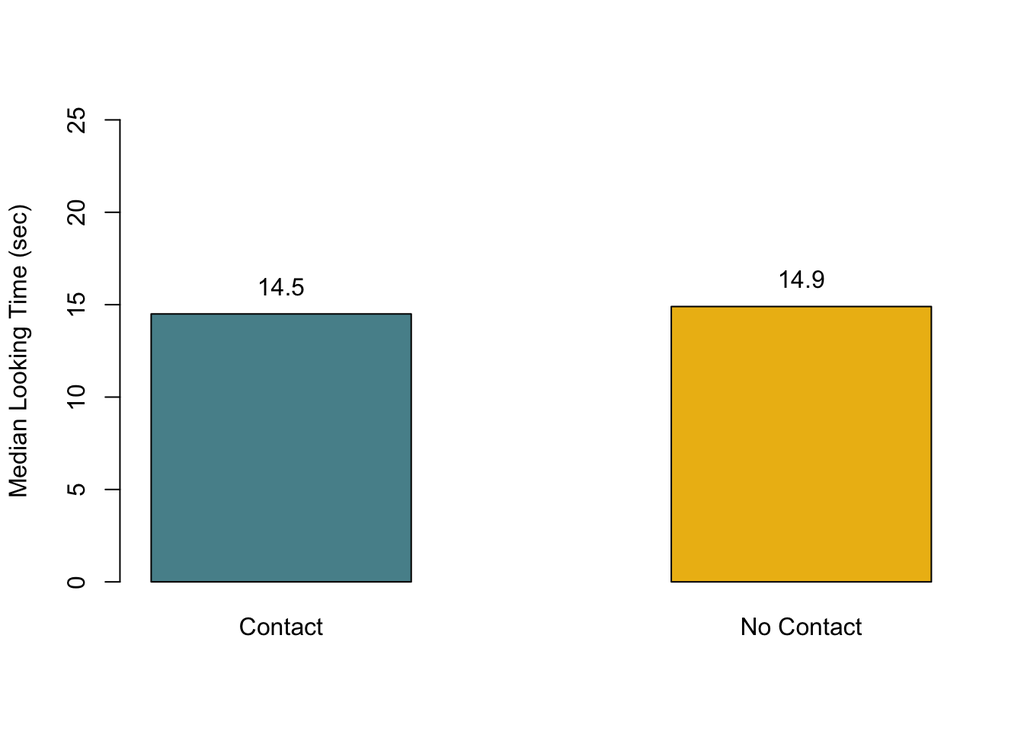

There was no difference in looking times between the first Contact test event (Median = 14.5) and the first No Contact event (Median = 14.9) between subjects, (Wilcoxon *Z* = -0.41, *p* = 0.68)

## Bar Graph: Means of first trial (Between-Subject)

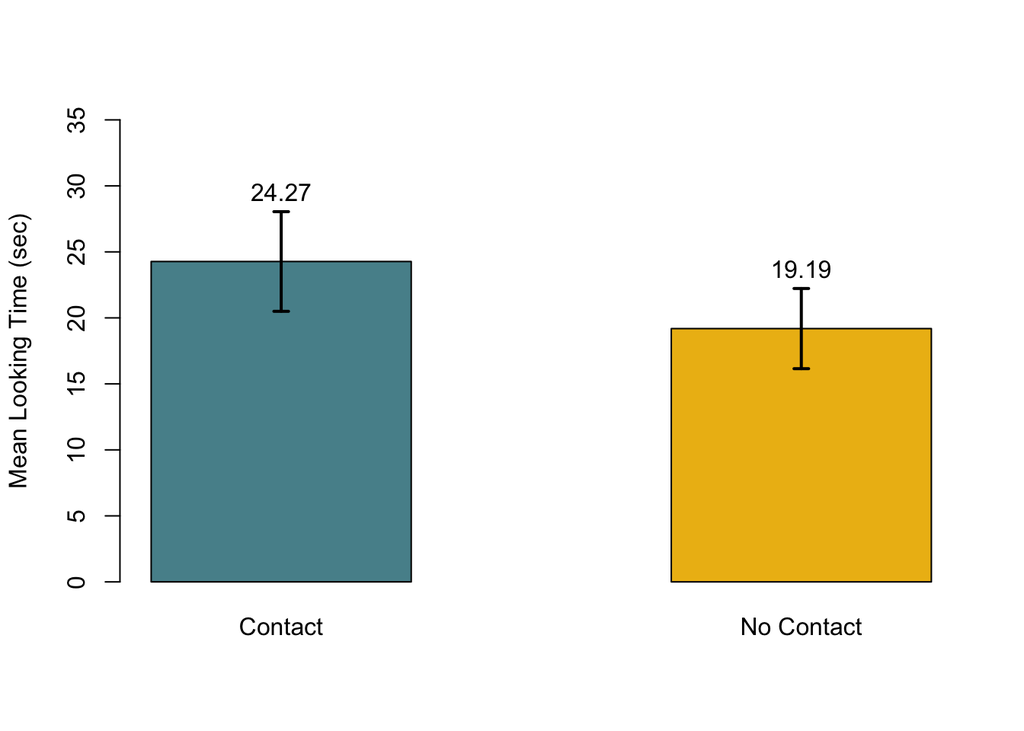

There was no difference in looking times between the first Possible test event (M = 24.27) and the first Impossible event (M = 19.19) between subjects, (t(51.06) = -1.05, *p* = 0.3).

# Dishabituation Analyses

### (Difference between last familiarization and first test)

Positive values indicate dishabituation (renewed interest), negative values indicate no dishabituation

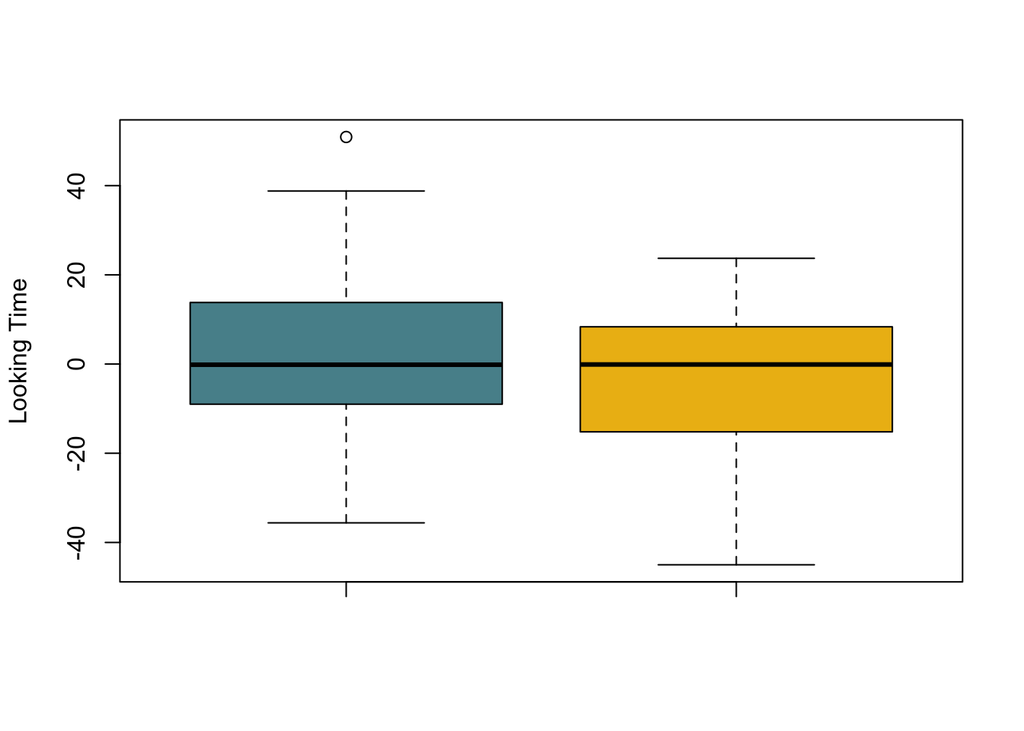

## Bar Graph: Median of Dishabituation

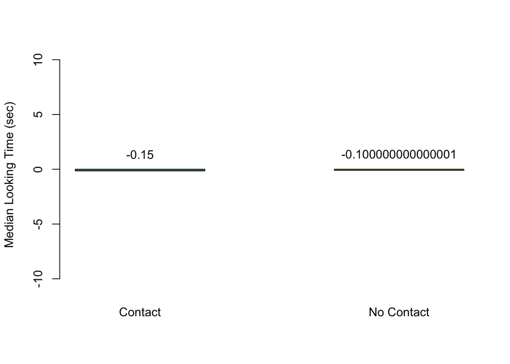

There was no difference in dishabituation to the first Contact test event (Median = -0.15) and dishabituation to the first No Contact event (Median = -0.1), (Wilcoxon *Z* = -0.83, *p* = 0.4)

## Bar Graph: Mean of dishabituation

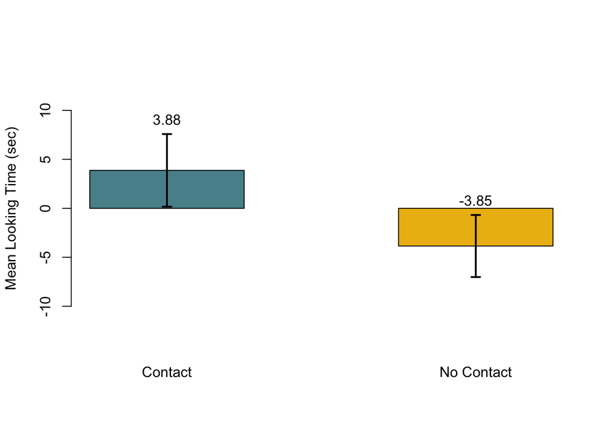

There was no difference in dishabituation to the first Possible test event (M = 3.88) and dishabituation to the first Impossible event (M = -3.85), (t(52.02) = -1.58, *p* = 0.12).

## Breakdown of young (<=7.3 months) vs old infants (> 7.3)

|  | 1 | 2 |
| --- | --- | --- |
| **FALSE** | 10 | 15 |
| **TRUE** | 18 | 12 |

|  | Male | Female |
| --- | --- | --- |
| **FALSE** | 14 | 11 |
| **TRUE** | 15 | 15 |

Infants younger than 7.3 months

|  | 1 | 2 |
| --- | --- | --- |
| **Male** | 10 | 5 |
| **Female** | 8 | 7 |

Infants older than 7.3 months

|  | 1 | 2 |
| --- | --- | --- |
| **Male** | 5 | 9 |
| **Female** | 5 | 6 |

There were 30 less than or equal to 7.3 months old. There were 25 greater than or equal to 7.3 months old.

# Bar Graph: Mean Looking Time across Trials (Young vs Old)

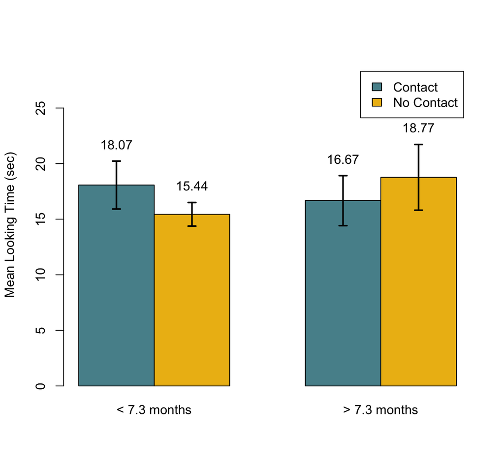

# Bar Graph: Mean Looking Time on First Trial (Young vs Old)

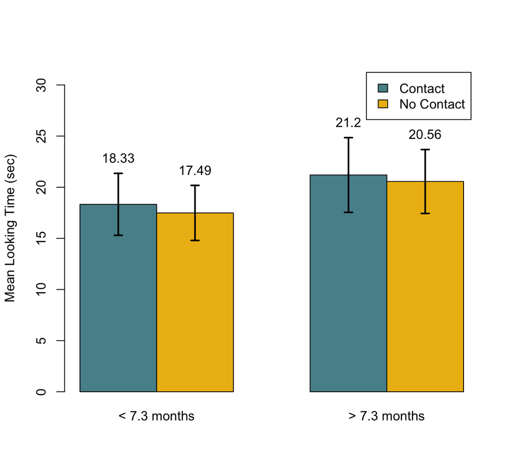

For infants younger than 7.3 months, there was no difference in looking times between the first Possible test event (M = 18.33) and the first Impossible event (M = 17.49), (t(29) = -0.24, *p* = 0.81).

For infants older than 7.3 months, there was no difference in looking times between the first Possible test event (M = 21.2) and the first Impossible event (M = 20.56), (t(24) = -0.2, *p* = 0.85).

# Bar Graph: Mean Looking Time on Third Trial (Young vs Old)

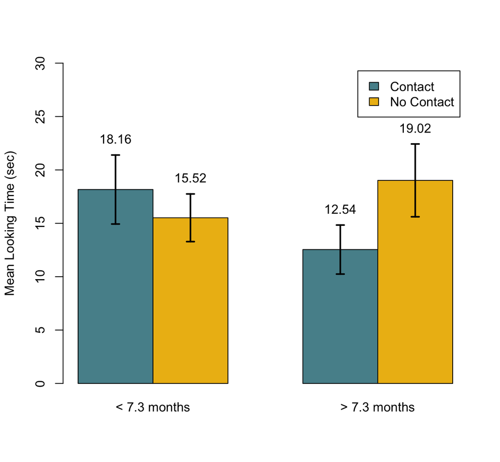

For infants younger than 7.3 months, there was no difference in looking times between the third Possible test event (M = 18.16) and the third Impossible event (M = 15.52), (t(29) = -0.89, *p* = 0.38).

For infants older than 7.3 months, there was no difference in looking times between the third Possible test event (M = 12.54) and the third Impossible event (M = 19.02), (t(24) = 1.97, *p* = 0.06).